# WITM-Analisys Q2

2024-09-12

#WITM Q2 analysis

*Q2. Which of the following statements best describes your group, organization and/or movement? Hint: by “intersecting identities,” we refer to multiple and overlapping factors, including but not limited to gender identity, race, ethnicity, class, migration status, religious beliefs, sexual expression and identity, etc.

1. We promote the rights of women or girls or trans or gender diverse people with intersecting identities, and this is the “primary focus of all our work”.
2. We promote the rights of women or girls or trans or gender diverse people with intersecting identities “through specific project(s)”, but not as the primary focus of our work.
3. Other (please briefly share to what extent the rights of women, girls, trans or gender diverse people are a priority for your work)

**-.-.-.-.-.-.-.-.-.-.-.-.-.-.-.-.-.-.-.-.-.-.-.-.-.-.-.-.-.-**

**Group information:**

Q2. Which of the following statements best describes your group, organization and/or movement?

Description

n

porcentaje

1. Feministe organizations (primary focus)

924

74.0

2. Organizations that promote the rights of women or girls through specific project(s) (specific_projects)

232

18.6

3. Other

93

7.4

-.-.-.-.-.-.-.-.-.-.-.-.-.-.-.-.-.-.-.-.-.-.-.-.-.-.-.-.-.-

Most of the organizations are feminist (primary focus). The 7% can be reduced by cleaning and some can also be reassigned from group b) to a).

-.-.-.-.-.-.-.-.-.-.-.-.-.-.-.-.-.-.-.-.-.-.-.-.-.-.-.-.-.-

**q2 croostab with q4 grouped on AWID Spotlight themes/groups**

q4_awid_focus

3. Other
1. Primary focus
2. Specific project(s)

Other subjects

17.2

18.5

23.6

Spotlight

82.8

81.5

76.4

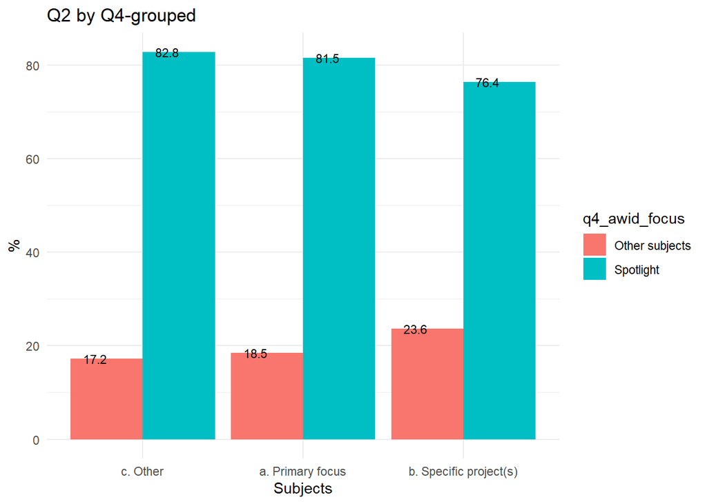

-.-.-.-.-.-.-.-.-.-.-.-.-.-.-.-.-.-.-.-.-.-.-.-.-.-.-.-.-.-

The data show that primary focus organizations work proportionally more on AWID’s priority issues than “per project” organizations. Even so, the difference (81.5 vs. 76.4) is not very significant (around 5%).

-.-.-.-.-.-.-.-.-.-.-.-.-.-.-.-.-.-.-.-.-.-.-.-.-.-.-.-.-.-

**q2 croostab with q5 registration**

q5_registered

3. Other
1. Primary focus
2. Specific project(s)

No

20.2

17.4

18

Yes

79.8

82.6

82

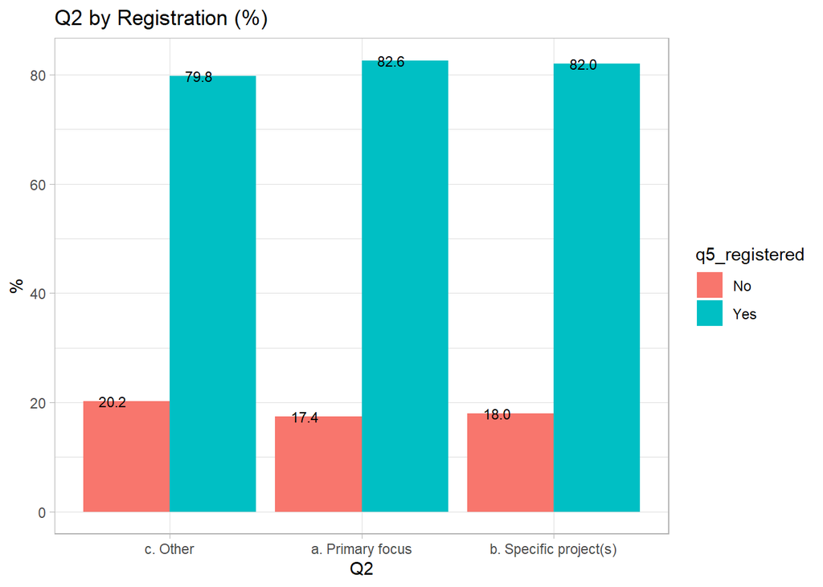

-.-.-.-.-.-.-.-.-.-.-.-.-.-.-.-.-.-.-.-.-.-.-.-.-.-.-.-.-.-

There is no significant difference in registration between Primary focus organizations and project organizations.

-.-.-.-.-.-.-.-.-.-.-.-.-.-.-.-.-.-.-.-.-.-.-.-.-.-.-.-.-.-

**q2 croostab with q6 Scope**

q6_geo_scope

3. Other
1. Primary focus
2. Specific project(s)

diaspora_and_or_exile

3.2

1.3

NA

globally_focused

5.4

6.2

5.2

locally_focused

21.5

31.8

33.2

nationally_focused

57.0

49.1

46.6

regionally_focused

8.6

9.7

10.8

transnationally_focused

4.3

1.8

4.3

-.-.-.-.-.-.-.-.-.-.-.-.-.-.-.-.-.-.-.-.-.-.-.-.-.-.-.-.-.-

There is also no difference in how the geographic scope is distributed between the two types of organizations. If they were very different types of organizations, one would have expected the project organizations to be more global or regional, but this is not observed in the data.

-.-.-.-.-.-.-.-.-.-.-.-.-.-.-.-.-.-.-.-.-.-.-.-.-.-.-.-.-.-

**q2 by year of formation**

q9_year_formation_agrup

3. Other
1. Primary focus
2. Specific project(s)
1. 2021-2023

12.9

15.2

17.2

2. From 2015 to 2020

32.3

32.4

34.9

3. From 2010 to 2014

18.3

18.7

15.9

4. From 2000 to 2009

19.4

20.3

19.4

5. Before 2000

17.2

13.4

12.5

-.-.-.-.-.-.-.-.-.-.-.-.-.-.-.-.-.-.-.-.-.-.-.-.-.-.-.-.-.-

-.-.-.-.-.-.-.-.-.-.-.-.-.-.-.-.-.-.-.-.-.-.-.-.-.-.-.-.-.-

**q2 by budget**

q10_budget_grp_2021

3. Other
1. Primary focus
2. Specific project(s)
1. Zero budget

23.3

14.5

15.6

2. <5000

22.1

18.1

21.0

3. 5001-10000

10.5

11.7

12.7

4. 10001-30000

14.0

13.6

12.2

5. 30001 -50000

9.3

8.8

8.3

6. 50001 - 100000

4.7

9.9

10.2

7. 100,001 – 500,001 USD

10.5

15.4

12.2

8. 500,001 – $1,000,000 USD

2.3

5.2

2.9

1. 1,000,001 + USD

3.5

2.9

4.9

-.-.-.-.-.-.-.-.-.-.-.-.-.-.-.-.-.-.-.-.-.-.-.-.-.-.-.-.-.-

In relation to the budget, as can be seen, the distribution of the budget ranges are similar between the primary focus group and specific projects, especially the most important was to analyze the extremes (zero budgeted) and the highest ranges. In neither of these groups is there any distinctive trend between the two groups.

-.-.-.-.-.-.-.-.-.-.-.-.-.-.-.-.-.-.-.-.-.-.-.-.-.-.-.-.-.-

**Q2 by Q13 external funding**

q13_ext_funding

3. Other
1. Primary focus
2. Specific project(s)

no

31.2

27.1

35.8

yes

68.8

72.9

64.2

-.-.-.-.-.-.-.-.-.-.-.-.-.-.-.-.-.-.-.-.-.-.-.-.-.-.-.-.-.-

This is the first variable that shows a more significant difference, but with the opposite result to the expected: organizations working on a project basis are less likely to rely on external funding (64%) than targeted organizations (72.9).

-.-.-.-.-.-.-.-.-.-.-.-.-.-.-.-.-.-.-.-.-.-.-.-.-.-.-.-.-.-

Description

3. Other
1. Primary focus
2. Specific project(s)

Multirateral

12.5

18.2

17.4

Bilateral

18.8

19.0

21.5

Philanthropic

23.4

31.6

36.9

Feminist

39.1

58.6

47.7

Private

6.2

10.8

12.1

INGOS

46.9

34.3

36.9

Individual

15.6

23.9

24.8

Government

6.2

15.0

20.1

Other

7.8

4.9

6.7

-.-.-.-.-.-.-.-.-.-.-.-.-.-.-.-.-.-.-.-.-.-.-.-.-.-.-.-.-.-

Regarding the sources of funding, there are some differences: primary focus organizations have a higher proportion of feminist funding (58.6% vs. 47.7%) and less funding from governments (15 vs. 20).

The overall distribution is however similar.

-.-.-.-.-.-.-.-.-.-.-.-.-.-.-.-.-.-.-.-.-.-.-.-.-.-.-.-.-.-

**Q2 by Q21**

**core funding**

q21_core_2023

3. Other
1. Primary focus
2. Specific project(s)

1 Up to 25%

78.1

59.8

69.8

2 Between 26%-50%

14.1

23.0

16.1

3 Between 51%-75%

7.8

7.9

7.4

4 Over 75%

NA

9.3

6.7

**Proyect funding**

q21_project_2023

3. Other
1. Primary focus
2. Specific project(s)

1 Up to 25%

34.4

30.6

34.9

2 Between 26%-50%

28.1

24.6

22.1

3 Between 51%-75%

12.5

17.2

14.8

4 Over 75%

25.0

27.6

28.2

**Emergency funding**

q21_emergency_2023

3. Other
1. Primary focus
2. Specific project(s)

1 Up to 25%

82.8

92.3

90.6

2 Between 26%-50%

14.1

6.2

8.1

3 Between 51%-75%

1.6

0.7

0.7

4 Over 75%

1.6

0.7

0.7

-.-.-.-.-.-.-.-.-.-.-.-.-.-.-.-.-.-.-.-.-.-.-.-.-.-.-.-.-.-

-.-.-.-.-.-.-.-.-.-.-.-.-.-.-.-.-.-.-.-.-.-.-.-.-.-.-.-.-.-

-.-.-.-.-.-.-.-.-.-.-.-.-.-.-.-.-.-.-.-.-.-.-.-.-.-.-.-.-.- -.-.-.-.-.-.-.-.-.-.-.-.-.-.-.-.-.-.-.-.-.-.-.-.-.-.-.-.-.-

**CONCLUSION**

The latter (by project) work less frequently on AWID’s priority issues (5% difference less, very little) and are registered in the same proportion as feminists (focus).

The geographical scope is also equivalent, for example, some are not more global and others more local, and they behave in the same way in relation to the year of training.

Up to this point, there are NO significant differences in any aspect.

Moving on to the analysis in relation to budget and funding, there are also minor differences in relation to budget, with only a slight tendency that project-based organizations seem to have lower budgets than feminist ones (slightly).

Along the same lines, another slightly different variable indicates that feminist organizations have a higher proportion of core funding than those working on a project basis.

-.-.-.-.-.-.-.-.-.-.-.-.-.-.-.-.-.-.-.-.-.-.-.-.-.-.-.-.-.- -.-.-.-.-.-.-.-.-.-.-.-.-.-.-.-.-.-.-.-.-.-.-.-.-.-.-.-.-.-